# Time Interval vs. Steps

**1. Code for reading in the dataset and/or processing the data**  
**2. Histogram of the total number of steps taken each day**

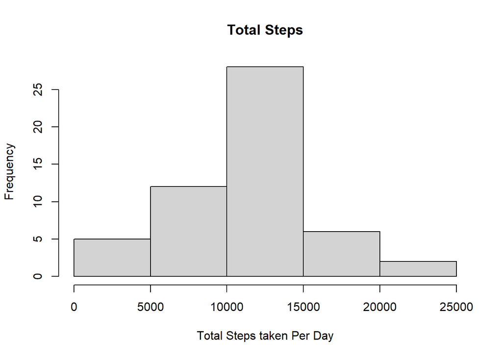

```r
setwd('C:/R_studio/reproducible research/week2ass/repdata_data_activity')
data <- read.csv("activity.csv")
tsteps <- tapply(data$steps, data$date, FUN=sum)

hist(tsteps, main='Total Steps', xlab='Total Steps taken Per Day')
```

**3. Mean and median number of steps taken each day**

```r
totsteps <- tapply(data$steps, data$date, sum, na.rm=T)
ave <- mean(totsteps)
med <- median(totsteps)
```

The mean number of steps per day is: **`9354.2295082`**  
The median number of steps per day is: **`10395`**

**4. Time series plot of the average number of steps taken**

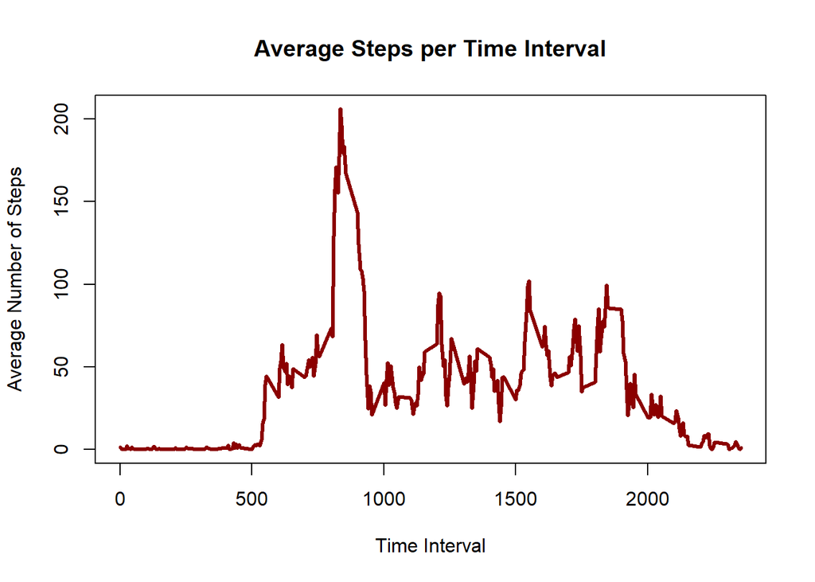

```r
stepsint <- tapply(data$steps, data$interval, mean, na.rm=T)
plot(names(stepsint), stepsint,xlab = 'Time Interval', ylab='Average Number of Steps', main='Average Steps per Time Interval', type='l', lwd=3, col ='dark red')
```

**5. The 5-minute interval that, on average, contains the maximum number of steps**

```r
maxint <- subset(stepsint, stepsint==max(stepsint))
name <- names(maxint)
```

The time interval that, on average, has the highest number of steps is **`835`**.

To show how many missing values are in the data set:

```r
cntsteps <-sum(is.na(data$steps))
cntday <- sum(is.na(data$date))
cntint <- sum(is.na(data$interval))
```

There are **`2304`** missing step values in the data set.  
There are **`0`** missing days and **`0`** missing intervals.

**6.Code to describe and show a strategy for imputing missing data**  
To account for the missing values the NAs were estimated using the mean for the time interval on each specific week day. I chose to do this assuming that patterns are relatively close to each other week to week. but one week day might look different from the next. To give the most accurate estimation the time interval should be as specific as possible.

```r
library(dplyr)
library(stringi)
data_nona <- data

day <- weekdays(as.Date(data$date))
data1<-data
data1 <- cbind(data1, day)
data_nona<- cbind(data_nona,day)
ave_steps_dateandint <- aggregate(data1[,1], data1[,c(3,4)], mean, na.rm=T)

for( i in 1:length(data1[,1])){
      if(is.na(data1[i,1])){
            data_nona[i,1]<- stri_replace_na(data1[i,1], subset(ave_steps_dateandint, ave_steps_dateandint[,1]==data1[i,3] & ave_steps_dateandint[,2]==data1[i,4],x))
      }
}
totna <- sum(is.na(data_nona))
```

There are now **`0`** NA values in the data set.

**7.Histogram of the total number of steps taken each day after missing values are imputed**  
The NAs were changed into average values which means the total steps per day would look different.  
Here is a histogram showing this change.

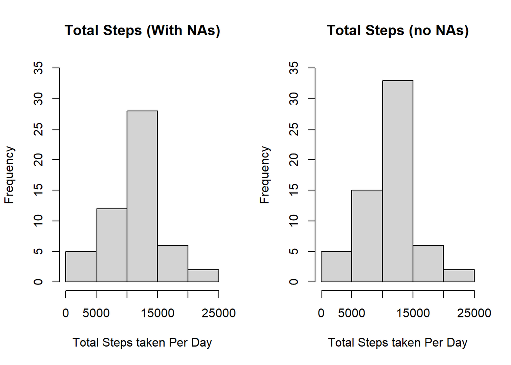

```r
sum_nona <- tapply(as.numeric(data_nona$steps), data_nona$date, sum, na.rm=T)

par(mfrow=c(1,2))
hist(tsteps, main='Total Steps (With NAs)', xlab='Total Steps taken Per Day', ylim=range(c(0,35)))
hist(sum_nona, main='Total Steps (no NAs)', xlab= 'Total Steps taken Per Day', ylim=range(c(0,35)))
```

Here is a new average and mean to show what the effect of NAs had on what the data could look like with the NAs changed into estimated values.

```r
totsteps_nona <- tapply(as.numeric(data_nona$steps), data_nona$date, sum)
ave_nona <- mean(totsteps_nona)
med_nona <- median(totsteps_nona)

difav <- ave_nona-ave
meddiff <- med_nona-med
```

The average number of steps per day is: **`1.082121\times 10^{4}`** steps per day  
The average number of steps per day without NAs is **`1466.9800937`** steps higher than with NAs.  
The median number of steps per day is: **`1.1015\times 10^{4}`** steps per day  
The median number of steps per day is **`620`** steps higher than with NAs.

**8. Panel plot comparing the average number of steps taken per 5-minute interval across weekdays and weekends** I had trouble getting the line graph to look okay. I ran the smooth line and liked the way it looked and thought it gave a good representation of the graph.

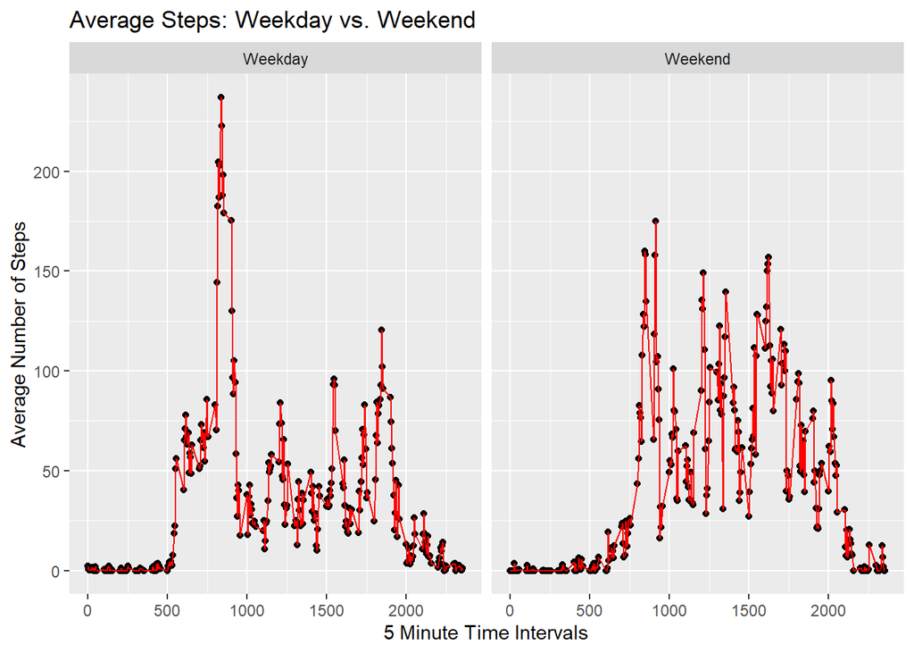

```r
library(ggplot2)
dayfactor <- c()
for(i in 1:length(data_nona[,1])){
      if(data_nona[i,4]=='Monday'|data_nona[i,4]=='Tuesday'|data_nona[i,4]=='Wednesday'|data_nona[i,4]=='Thursday'|data_nona[i,4]=='Friday'){
            dayfactor<- c(dayfactor,'Weekday')
      }
      else{
            dayfactor<-c(dayfactor,'Weekend')
      }
}
data_nona<- cbind(data_nona, dayfactor)
timeintave <-  aggregate(as.numeric(data_nona[,1]), data_nona[,c(3,5)], mean, na.rm=T)

dayendplot<-qplot(interval, x, data=timeintave, facets=.~dayfactor, type='l', main='Average Steps: Weekday vs. Weekend', ylab='Average Number of Steps',xlab='5 Minute Time Intervals')
dayendplot+geom_line(color='red')
```

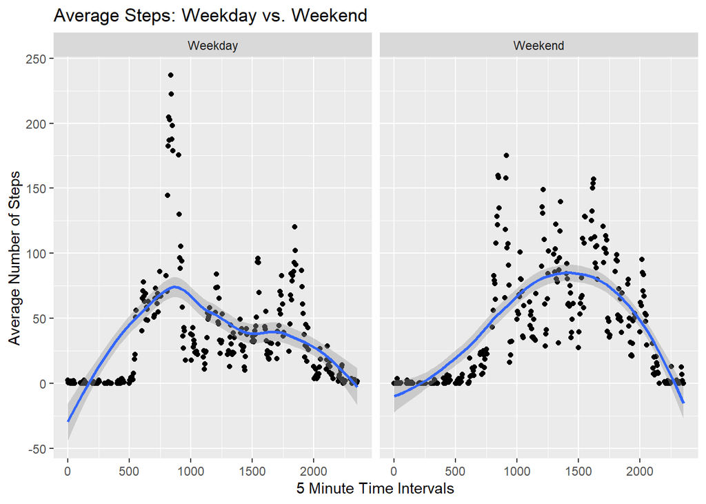

```r
dayendplot+geom_smooth(method='loess')
```

With the scatter plot, you can see the spike of steps during a specific time interval during the weekdays and it helps with the visualization of individual average values. After adding the smooth line to the graphs, you can see that overall steps is slightly higher and higher for a longer duration on the weekend compared to the weekdays even though the weekdays has a higher spike in amount of steps.